# Bayes Rule

Simon Halliday

2015-October -27

## Load packages

```r
library(mosaic)
```

## Bayes Rule

In Chapter 5, Cartwright refers to Bayes’ Rule. Let’s introduce Bayes’ Rule as a function in R. We need a function of the probability that the outcome is true given the “signal” $\theta$, or, phrased differently, given some “data” (often called D.) Therefore, we’re looking for something like:

```r
bayesrule <- function(p, theta) {
  (theta * p) / (theta * p + ( 1 - theta)*(1 - p))
}
```

Now that we have a function called `bayesrule()`, we can specify values for theta and p in order to get `bayesrule()` to take the values of theta and p as arguments. Let’s use the values Cartwright initially suggests:

```r
theta <- 0.9
p <- 0.4
bayesrule(p, theta)
```

```
## [1] 0.8571429
```

If we wanted to, we could substitute in new values for theta and p, as below:

```r
theta <- 0.7
p <- 0.5
bayesrule(p, theta)
```

```
## [1] 0.7
```

Notice how when p = 0.5, the probability that the outcome is true is simply the accuracy of the signal (here 0.7). So when you “trust” your friend 70% and you are fifty-fifty in your preferences, you’ll be 70% likely to go with what your friend suggests untill you encounter a new signal (or new data).

## Models of Choice with uncertainty

```r
ufn1 <- function(w){
  (w)^(0.5)
}
wealth <- 0
winnings <- 2
u1 <- ufn1(wealth + winnings)
u2 <- ufn1(wealth)
p <- 0.6
exp.u <- function(p, u1, u2) {
  p*u1 + (1 - p)*(u2)
}
exp.u(p, u1, u2)
```

```
## [1] 0.8485281
```

## Gambler’s Fallacy

The gambler’s fallacy: we do not expect many heads (or tails) in a row, even though that could occur totally randomly

```r
c1 <- rflip(50)
c1
```

```
##
## Flipping 50 coins [ Prob(Heads) = 0.5 ] ...
##
## T T H T H T H H T H T T T H H T H T H H T H T T H H T H H H H T H T H H T H H T T H H T T T T T H T
##
## Number of Heads: 25 [Proportion Heads: 0.5]
```

```r
cartwright2 <- data.frame(c("H", "T", "T", "H", "H", "H", "T", "T", "H", "T", "T", "H", "T", "H", "H", "T", "H", "T", "T", "T", "H", "H", "T", "H", "H", "H", "T", "H", "T", "T", "H", "H", "T", "H", "T", "T", "T", "H", "H", "T", "H", "H", "T", "T", "T", "H", "T", "H", "H", "T"))
colnames(cartwright2) <- c("heads")
cartwright2
```

```
##    heads
## 1      H
## 2      T
## 3      T
## 4      H
## 5      H
## 6      H
## 7      T
## 8      T
## 9      H
## 10     T
## 11     T
## 12     H
## 13     T
## 14     H
```

[output cut: 36 more lines]

```r
tally(~ heads, data = cartwright2)
```

```
##
##  H  T
## 25 25
```

```r
c3 <- rflip(50)
c3
```

```
##
## Flipping 50 coins [ Prob(Heads) = 0.5 ] ...
##
## H H T H T T H H T H T H T H T T T T T T T T H H T T H H H T H T H T T T H T T T H T T H T T T T H H
##
## Number of Heads: 20 [Proportion Heads: 0.4]
```

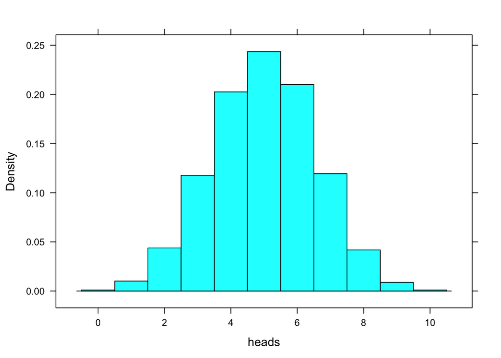

```r
GamblersFal <- do(5000) * rflip(10)
histogram( ~ heads, data = GamblersFal, width = 1 )
```

## Checking values of Bayes Rule in a Table

I didn’t end up using this. Ignore it. I’m keeping it here for my notes later.

```r
theta.tab <- seq(0.1, 1, by = 0.1)
p.tab <- seq(0.1, 1, by = 0.1)
ptheta <- data.frame(theta.tab, p.tab)
```